# Metrolinx_Preprocessing_Raw_Data

```python
# !pip install --trusted-host pypi.org --trusted-host pypi.python.org --trusted-host files.pythonhosted.org plotly
```

## Import Libraries

```python
import pandas as pd
import os
import numpy as np
import missingno
```

## Load Data

```python
path =  os.getcwd()
path
```

```
'C:\\Users\\DKici\\Desktop\\Metrolinx\\notebook'
```

```python
data =  pd.read_excel(f"{path}\\input_data\\interview_dataset.xlsx")
data.head()
```

|  | Year | Month | Day | Week Number | Rail Corridor | Weekend&Holidays/weekday | Station | Time Period | Ridership | Total Train Trips |
| --- | --- | --- | --- | --- | --- | --- | --- | --- | --- | --- |
| 0 | 2019 | January | 1 | 1 | Barrie | weekend | ALLANDALE WATERFRONT GO | Weekend/Holiday | 174 | 3 |
| 1 | 2019 | January | 1 | 1 | Barrie | weekend | AURORA GO | Weekend/Holiday | 379 | 10 |
| 2 | 2019 | January | 1 | 1 | Barrie | weekend | UNION STATION | Weekend/Holiday | 596 | 12 |
| 3 | 2019 | January | 1 | 1 | Lakeshore East | weekend | ALDERSHOT GO | Weekend/Holiday | 2759 | 35 |
| 4 | 2019 | January | 1 | 1 | Lakeshore East | weekend | OSHAWA GO | Weekend/Holiday | 2623 | 36 |

```python
# Stripping out spaces from ends of names, and replacing internal spaces or different characters with "_"
data.columns = [col.strip().replace(' ', '_').lower() for col in data.columns]
data.columns = [col.strip().replace('-', '_').lower() for col in data.columns]
data.columns = [col.strip().replace('&', '_').lower() for col in data.columns]
data.columns = [col.strip().replace('/', '_').lower() for col in data.columns]
data
```

|  | year | month | day | week_number | rail_corridor | weekend_holidays_weekday | station | time_period | ridership | total_train_trips |
| --- | --- | --- | --- | --- | --- | --- | --- | --- | --- | --- |
| 0 | 2019 | January | 1 | 1 | Barrie | weekend | ALLANDALE WATERFRONT GO | Weekend/Holiday | 174 | 3 |
| 1 | 2019 | January | 1 | 1 | Barrie | weekend | AURORA GO | Weekend/Holiday | 379 | 10 |
| 2 | 2019 | January | 1 | 1 | Barrie | weekend | UNION STATION | Weekend/Holiday | 596 | 12 |
| 3 | 2019 | January | 1 | 1 | Lakeshore East | weekend | ALDERSHOT GO | Weekend/Holiday | 2759 | 35 |
| 4 | 2019 | January | 1 | 1 | Lakeshore East | weekend | OSHAWA GO | Weekend/Holiday | 2623 | 36 |
| ... | ... | ... | ... | ... | ... | ... | ... | ... | ... | ... |
| 64364 | 2022 | December | 31 | 52 | Lakeshore West | weekend | WEST HARBOUR GO | Weekend/Holiday | 2578 | 19 |
| 64365 | 2022 | December | 31 | 52 | Milton | weekend | MILTON GO | Weekend/Holiday | 72 | 2 |
| 64366 | 2022 | December | 31 | 52 | Stouffville | weekend | MOUNT JOY GO | Weekend/Holiday | 685 | 12 |
| 64367 | 2022 | December | 31 | 52 | Stouffville | weekend | OLD ELM GO | Weekend/Holiday | 83 | 3 |
| 64368 | 2022 | December | 31 | 52 | Stouffville | weekend | UNION STATION | Weekend/Holiday | 418 | 15 |

64369 rows × 10 columns

```python
data= data.replace('[\$,/]', '', regex=True)
data.head(20)
```

|  | year | month | day | week_number | rail_corridor | weekend_holidays_weekday | station | time_period | ridership | total_train_trips |
| --- | --- | --- | --- | --- | --- | --- | --- | --- | --- | --- |
| 0 | 2019 | January | 1 | 1 | Barrie | weekend | ALLANDALE WATERFRONT GO | WeekendHoliday | 174 | 3 |
| 1 | 2019 | January | 1 | 1 | Barrie | weekend | AURORA GO | WeekendHoliday | 379 | 10 |
| 2 | 2019 | January | 1 | 1 | Barrie | weekend | UNION STATION | WeekendHoliday | 596 | 12 |
| 3 | 2019 | January | 1 | 1 | Lakeshore East | weekend | ALDERSHOT GO | WeekendHoliday | 2759 | 35 |
| 4 | 2019 | January | 1 | 1 | Lakeshore East | weekend | OSHAWA GO | WeekendHoliday | 2623 | 36 |
| 5 | 2019 | January | 1 | 1 | Lakeshore East | weekend | UNION STATION | WeekendHoliday | 26 | 1 |
| 6 | 2019 | January | 1 | 1 | Lakeshore West | weekend | ALDERSHOT GO | WeekendHoliday | 3321 | 35 |
| 7 | 2019 | January | 1 | 1 | Lakeshore West | weekend | OSHAWA GO | WeekendHoliday | 3721 | 36 |
| 8 | 2019 | January | 1 | 1 | Lakeshore West | weekend | UNION STATION | WeekendHoliday | 14 | 1 |
| 9 | 2019 | January | 2 | 1 | Barrie | weekday | ALLANDALE WATERFRONT GO | AM Peak | 3517 | 6 |
| 10 | 2019 | January | 2 | 1 | Barrie | weekday | ALLANDALE WATERFRONT GO | Midday | 701 | 1 |
| 11 | 2019 | January | 2 | 1 | Barrie | weekday | AURORA GO | Evening | 38 | 3 |
| 12 | 2019 | January | 2 | 1 | Barrie | weekday | AURORA GO | Midday | 267 | 4 |
| 13 | 2019 | January | 2 | 1 | Barrie | weekday | AURORA GO | PM Peak | 68 | 1 |
| 14 | 2019 | January | 2 | 1 | Barrie | weekday | BRADFORD GO | AM Peak | 184 | 1 |
| 15 | 2019 | January | 2 | 1 | Barrie | weekday | BRADFORD GO | Midday | 420 | 2 |
| 16 | 2019 | January | 2 | 1 | Barrie | weekday | UNION STATION | Evening | 980 | 7 |
| 17 | 2019 | January | 2 | 1 | Barrie | weekday | UNION STATION | Midday | 259 | 6 |
| 18 | 2019 | January | 2 | 1 | Barrie | weekday | UNION STATION | PM Peak | 3863 | 5 |
| 19 | 2019 | January | 2 | 1 | Kitchener | weekday | BRAMALEA GO | AM Peak | 162 | 1 |

## Data Exploration

```python
data.info()
```

```
<class 'pandas.core.frame.DataFrame'>
RangeIndex: 64369 entries, 0 to 64368
Data columns (total 10 columns):
 #   Column                    Non-Null Count  Dtype
---  ------                    --------------  -----
 0   year                      64369 non-null  int64
 1   month                     64369 non-null  object
 2   day                       64369 non-null  int64
 3   week_number               64369 non-null  int64
 4   rail_corridor             64369 non-null  object
 5   weekend_holidays_weekday  64369 non-null  object
 6   station                   64369 non-null  object
 7   time_period               64369 non-null  object
 8   ridership                 64369 non-null  int64
 9   total_train_trips         64369 non-null  int64
dtypes: int64(5), object(5)
memory usage: 4.9+ MB
```

```python
data.isnull().sum()
```

```
year                        0
month                       0
day                         0
week_number                 0
rail_corridor               0
weekend_holidays_weekday    0
station                     0
time_period                 0
ridership                   0
total_train_trips           0
dtype: int64
```

Any of the features has null data

-- There are 5 numeric features (all int): Year, Day, Week Number, Ridership and Total Train Trips

-- Year, Month, and Day can be combined to create Date feature

-- Month, Rail Corridor, Weekend&Holidays/weekday, Station, and Time Period are categorical

```python
data.columns
```

```
Index(['year', 'month', 'day', 'week_number', 'rail_corridor',
       'weekend_holidays_weekday', 'station', 'time_period', 'ridership',
       'total_train_trips'],
      dtype='object')
```

```python
categorical_features = data[['month', 'rail_corridor', 'weekend_holidays_weekday', 'station', 'time_period']]
categorical_features.nunique()
```

```
month                       12
rail_corridor                7
weekend_holidays_weekday     2
station                     45
time_period                  5
dtype: int64
```

```python
#Summary of the numerical features
numeric_features = data[['year','day','week_number','ridership','total_train_trips']]
numeric_features.describe()
```

|  | year | day | week_number | ridership | total_train_trips |
| --- | --- | --- | --- | --- | --- |
| count | 64369.000000 | 64369.000000 | 64369.000000 | 64369.000000 | 64369.000000 |
| mean | 2020.461853 | 15.790598 | 26.954186 | 1091.391415 | 5.618248 |
| std | 1.143510 | 8.750175 | 15.400862 | 1863.899736 | 5.955504 |
| min | 2019.000000 | 1.000000 | 1.000000 | 0.000000 | 0.000000 |
| 25% | 2019.000000 | 8.000000 | 13.000000 | 108.000000 | 2.000000 |
| 50% | 2020.000000 | 16.000000 | 27.000000 | 367.000000 | 4.000000 |
| 75% | 2022.000000 | 23.000000 | 41.000000 | 1135.000000 | 6.000000 |
| max | 2022.000000 | 31.000000 | 53.000000 | 26800.000000 | 50.000000 |

Let's look at a specific rail corridor and station at specific year

```python
#Simple Time Series Data
Barrie_Rides = data[(data['rail_corridor'] == 'Barrie') &
                     (data['year'] == 2019) &
                       (data['station'] == 'ALLANDALE WATERFRONT GO')]
Barrie_Rides.describe()
```

|  | year | day | week_number | ridership | total_train_trips |
| --- | --- | --- | --- | --- | --- |
| count | 608.0 | 608.000000 | 608.000000 | 608.000000 | 608.000000 |
| mean | 2019.0 | 15.771382 | 26.355263 | 2468.263158 | 3.615132 |
| std | 0.0 | 8.795238 | 15.107155 | 2055.496076 | 2.333744 |
| min | 2019.0 | 1.000000 | 1.000000 | 174.000000 | 1.000000 |
| 25% | 2019.0 | 8.000000 | 13.000000 | 844.750000 | 1.000000 |
| 50% | 2019.0 | 16.000000 | 26.000000 | 985.500000 | 5.000000 |
| 75% | 2019.0 | 23.000000 | 40.000000 | 4930.000000 | 6.000000 |
| max | 2019.0 | 31.000000 | 52.000000 | 6136.000000 | 10.000000 |

## Feature Engineering

Since this is a time series analysis, I create a Date column

```python
from time import strptime

data['Month'] = [strptime(str(i), '%B').tm_mon for i in data['month']]
data
```

|  | year | month | day | week_number | rail_corridor | weekend_holidays_weekday | station | time_period | ridership | total_train_trips | Month |
| --- | --- | --- | --- | --- | --- | --- | --- | --- | --- | --- | --- |
| 0 | 2019 | January | 1 | 1 | Barrie | weekend | ALLANDALE WATERFRONT GO | WeekendHoliday | 174 | 3 | 1 |
| 1 | 2019 | January | 1 | 1 | Barrie | weekend | AURORA GO | WeekendHoliday | 379 | 10 | 1 |
| 2 | 2019 | January | 1 | 1 | Barrie | weekend | UNION STATION | WeekendHoliday | 596 | 12 | 1 |
| 3 | 2019 | January | 1 | 1 | Lakeshore East | weekend | ALDERSHOT GO | WeekendHoliday | 2759 | 35 | 1 |
| 4 | 2019 | January | 1 | 1 | Lakeshore East | weekend | OSHAWA GO | WeekendHoliday | 2623 | 36 | 1 |
| ... | ... | ... | ... | ... | ... | ... | ... | ... | ... | ... | ... |
| 64364 | 2022 | December | 31 | 52 | Lakeshore West | weekend | WEST HARBOUR GO | WeekendHoliday | 2578 | 19 | 12 |
| 64365 | 2022 | December | 31 | 52 | Milton | weekend | MILTON GO | WeekendHoliday | 72 | 2 | 12 |
| 64366 | 2022 | December | 31 | 52 | Stouffville | weekend | MOUNT JOY GO | WeekendHoliday | 685 | 12 | 12 |
| 64367 | 2022 | December | 31 | 52 | Stouffville | weekend | OLD ELM GO | WeekendHoliday | 83 | 3 | 12 |
| 64368 | 2022 | December | 31 | 52 | Stouffville | weekend | UNION STATION | WeekendHoliday | 418 | 15 | 12 |

64369 rows × 11 columns

```python
data["date"] = pd.to_datetime(data[['year', 'Month', 'day']])
data.head()
```

|  | year | month | day | week_number | rail_corridor | weekend_holidays_weekday | station | time_period | ridership | total_train_trips | Month | date |
| --- | --- | --- | --- | --- | --- | --- | --- | --- | --- | --- | --- | --- |
| 0 | 2019 | January | 1 | 1 | Barrie | weekend | ALLANDALE WATERFRONT GO | WeekendHoliday | 174 | 3 | 1 | 2019-01-01 |
| 1 | 2019 | January | 1 | 1 | Barrie | weekend | AURORA GO | WeekendHoliday | 379 | 10 | 1 | 2019-01-01 |
| 2 | 2019 | January | 1 | 1 | Barrie | weekend | UNION STATION | WeekendHoliday | 596 | 12 | 1 | 2019-01-01 |
| 3 | 2019 | January | 1 | 1 | Lakeshore East | weekend | ALDERSHOT GO | WeekendHoliday | 2759 | 35 | 1 | 2019-01-01 |
| 4 | 2019 | January | 1 | 1 | Lakeshore East | weekend | OSHAWA GO | WeekendHoliday | 2623 | 36 | 1 | 2019-01-01 |

Since this is time series data, I will create time series for each different staion in each rail corridors.

```python
#This column is redundant since weekend had only one data as WeekendHoliday, and the rest of time period values belong to weekday.
# Then we know that if it is not WeekendHoliday, it is weekday.
data = data.drop(columns = 'weekend_holidays_weekday')
```

```python
data
```

|  | year | month | day | week_number | rail_corridor | station | time_period | ridership | total_train_trips | Month | date |
| --- | --- | --- | --- | --- | --- | --- | --- | --- | --- | --- | --- |
| 0 | 2019 | January | 1 | 1 | Barrie | ALLANDALE WATERFRONT GO | WeekendHoliday | 174 | 3 | 1 | 2019-01-01 |
| 1 | 2019 | January | 1 | 1 | Barrie | AURORA GO | WeekendHoliday | 379 | 10 | 1 | 2019-01-01 |
| 2 | 2019 | January | 1 | 1 | Barrie | UNION STATION | WeekendHoliday | 596 | 12 | 1 | 2019-01-01 |
| 3 | 2019 | January | 1 | 1 | Lakeshore East | ALDERSHOT GO | WeekendHoliday | 2759 | 35 | 1 | 2019-01-01 |
| 4 | 2019 | January | 1 | 1 | Lakeshore East | OSHAWA GO | WeekendHoliday | 2623 | 36 | 1 | 2019-01-01 |
| ... | ... | ... | ... | ... | ... | ... | ... | ... | ... | ... | ... |
| 64364 | 2022 | December | 31 | 52 | Lakeshore West | WEST HARBOUR GO | WeekendHoliday | 2578 | 19 | 12 | 2022-12-31 |
| 64365 | 2022 | December | 31 | 52 | Milton | MILTON GO | WeekendHoliday | 72 | 2 | 12 | 2022-12-31 |
| 64366 | 2022 | December | 31 | 52 | Stouffville | MOUNT JOY GO | WeekendHoliday | 685 | 12 | 12 | 2022-12-31 |
| 64367 | 2022 | December | 31 | 52 | Stouffville | OLD ELM GO | WeekendHoliday | 83 | 3 | 12 | 2022-12-31 |
| 64368 | 2022 | December | 31 | 52 | Stouffville | UNION STATION | WeekendHoliday | 418 | 15 | 12 | 2022-12-31 |

64369 rows × 11 columns

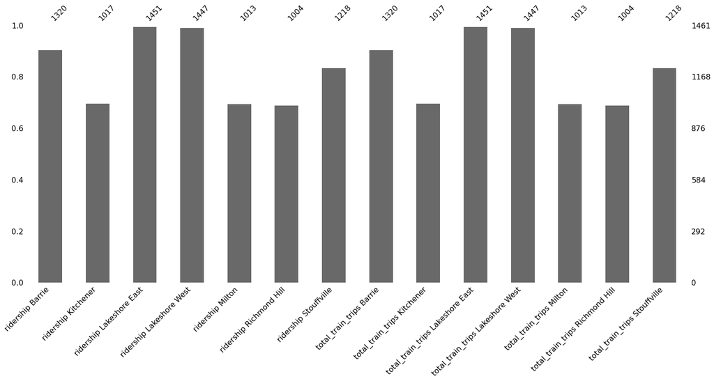

```python
df1 = pd.pivot_table(data, values=['ridership', 'total_train_trips'], index=['date'],
                       columns=['rail_corridor'], aggfunc=np.sum) #, fill_value=0
df1.columns = [' '.join(col).strip() for col in df1.columns.values]
df1.index.freq = 'd'
missingno.bar(df1)
```

These time series give us the total number of ridership (7 time series) and total_train_trips (7 time series) based for each rail_corridor. The lenght of each time series is 1461 (4 years data between 2019-2022) We can use the time components (year, month, day, and week numbers) as covariants as well as weekend/weekday and holiday or not. But we loose the peak time numbers of the weekdays in this level. The highest scacity is about 30%.

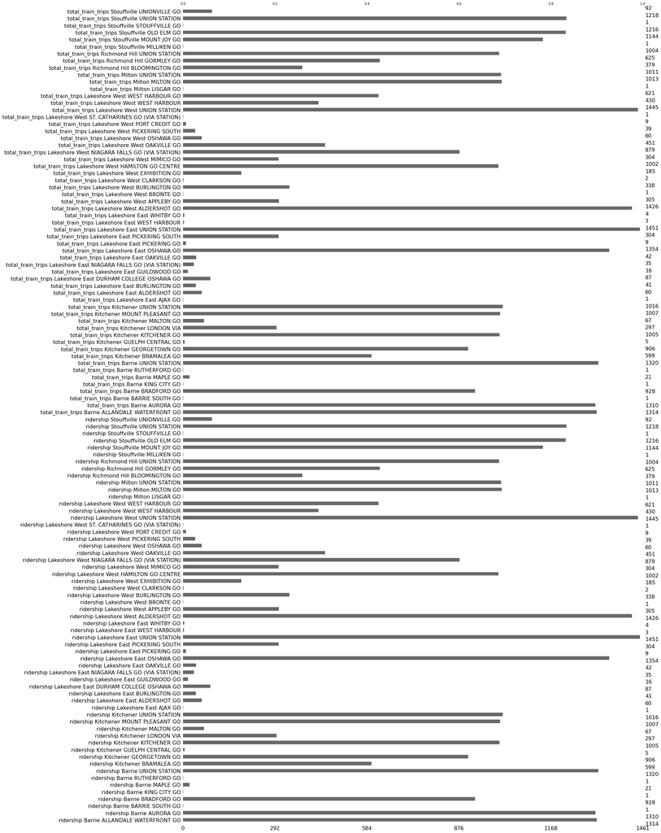

```python
df2 = pd.pivot_table(data, values=['ridership', 'total_train_trips'], index=['date'],
                       columns=['rail_corridor','station'], aggfunc=np.sum) #, fill_value=0
df2.columns = [' '.join(col).strip() for col in df2.columns.values]
df2.index.freq = 'd'
missingno.bar(df2)
```

These time series gives us total number of ridership (58 time series) and total_train_trips (58 time series) for each station in each rail corridor. Similarly, we can use the time components (year, month, day, and week numbers) as covariants as well as weekend/weekday and holiday or not. But we still loose the peak time numbers of the weekdays in this level.

Let's check the scarcity of the time series

[figure not shown]

```python
df3 = pd.pivot_table(data, values=['ridership', 'total_train_trips'], index=['date'],
                       columns=['rail_corridor','station', 'time_period'], aggfunc=np.sum) #, fill_value=0
df3.columns = [' '.join(col).strip() for col in df3.columns.values]
df3.index.freq = 'd'
missingno.bar(df3)
```

These third level time series gives us total number of ridership (179 time series) and total_train_trips (179 time series) for different peak days/times for each station in each rail corridor. This allows us to make our predictions for specific time period by suing not onlu the time components (year, month, day, and week numbers) as covariants as well as weekend/weekday and holiday or not. but also specific days and times of the days.

For example, the first level time series allow us to make prediction only for a specific region like Barrie. To make predictions for specific stations in Barries such as AURORA GO station, we need the second level time series. With the third level time series we can forecast the number of ridership and/or total_train_trips in Barrie, AURORA GO station in the Evening time, in the mid-day, or at PM peak.

On the other hand, as it is shown in the bar graphs above, the scarcity of these time series for the second and third level data is high. Then, most of these time series are not proper to be used to make predictions for that that specific times of the days.

I will select a few time series from for forecasting.

```python
df1
```

| date | ridership Barrie | ridership Kitchener | ridership Lakeshore East | ridership Lakeshore West | ridership Milton | ridership Richmond Hill | ridership Stouffville | total_train_trips Barrie | total_train_trips Kitchener | total_train_trips Lakeshore East | total_train_trips Lakeshore West | total_train_trips Milton | total_train_trips Richmond Hill | total_train_trips Stouffville |
| --- | --- | --- | --- | --- | --- | --- | --- | --- | --- | --- | --- | --- | --- | --- |
| 2019-01-01 | 1149.0 | NaN | 5408.0 | 7056.0 | NaN | NaN | NaN | 25.0 | NaN | 72.0 | 72.0 | NaN | NaN | NaN |
| 2019-01-02 | 10297.0 | 12586.0 | 25057.0 | 29978.0 | 14600.0 | 5940.0 | 9087.0 | 36.0 | 31.0 | 118.0 | 107.0 | 20.0 | 12.0 | 29.0 |
| 2019-01-03 | 11395.0 | 13476.0 | 27819.0 | 34463.0 | 15327.0 | 6139.0 | 9671.0 | 36.0 | 31.0 | 119.0 | 108.0 | 20.0 | 12.0 | 30.0 |
| 2019-01-04 | 9762.0 | 11701.0 | 25222.0 | 30343.0 | 13328.0 | 5396.0 | 8636.0 | 36.0 | 31.0 | 112.0 | 102.0 | 20.0 | 12.0 | 30.0 |
| 2019-01-05 | 1549.0 | NaN | 7751.0 | 11118.0 | NaN | NaN | NaN | 25.0 | NaN | 69.0 | 69.0 | NaN | NaN | NaN |
| ... | ... | ... | ... | ... | ... | ... | ... | ... | ... | ... | ... | ... | ... | ... |
| 2022-12-27 | 2358.0 | NaN | 7198.0 | 10672.0 | NaN | NaN | 1817.0 | 30.0 | NaN | 74.0 | 78.0 | NaN | NaN | 30.0 |
| 2022-12-28 | 2740.0 | 4405.0 | 9162.0 | 11942.0 | 1499.0 | 391.0 | 2250.0 | 32.0 | 46.0 | 82.0 | 92.0 | 12.0 | 7.0 | 33.0 |
| 2022-12-29 | 2876.0 | 4480.0 | 10168.0 | 13565.0 | 1481.0 | 376.0 | 2394.0 | 32.0 | 46.0 | 82.0 | 90.0 | 12.0 | 7.0 | 33.0 |
| 2022-12-30 | 2485.0 | 4124.0 | 9655.0 | 14064.0 | 1009.0 | 240.0 | 2036.0 | 32.0 | 46.0 | 82.0 | 91.0 | 12.0 | 7.0 | 33.0 |
| 2022-12-31 | 1788.0 | 532.0 | 4911.0 | 8579.0 | 72.0 | NaN | 1186.0 | 30.0 | 4.0 | 71.0 | 79.0 | 2.0 | NaN | 30.0 |

1461 rows × 14 columns

```python
data.to_csv(f"{path}/input_data/Metrolinx_prepocessed_data.csv")
df1.to_csv(f"{path}/input_data/Rail_Corridor_data.csv")
df2.to_csv(f"{path}/input_data/Station_data.csv")
df3.to_csv(f"{path}/input_data/Time_period_data.csv")
```

### Create Time Series at different Levels

```python
rc_names =[]
rc_st_names = []
rc_st_tp_names = []


# Rail Corridor
for rc in data.rail_corridor.unique():
    df_rc = data[(data["rail_corridor"] == rc)]
    df_rc.rail_corridor.unique()

    df_rc = pd.pivot_table(df_rc, values=['ridership', 'total_train_trips'], index=['date'],
                                           columns=['rail_corridor'], aggfunc=np.sum, fill_value=0)

    df_rc.columns = [' '.join(col).strip() for col in df_rc.columns.values]
    if len(df_rc) > 1000: #(4*365)*0.75:
        rc_names.append(f"Metrolinx_{rc}_Data")
        df_rc.to_csv(f"{path}/ts_data/Metrolinx_{rc}_Data.csv")

    # Rail Corridor and Station
    for st in data.station.unique():
        df_rc_st = data[(data["rail_corridor"] == rc) & (data["station"] == st)]
        df_rc_st = pd.pivot_table(df_rc_st, values=['ridership', 'total_train_trips'], index=['date'],
                       columns=['rail_corridor', 'station'], aggfunc=np.sum, fill_value=0)
        df_rc_st.columns = [' '.join(col).strip() for col in df_rc_st.columns.values]
        if len(df_rc_st) > 1000: #(4*365)*0.75:
            rc_st_names.append(f"Metrolinx_{rc}_{st}_Data")
            df_rc_st.to_csv(f"{path}/ts_data/Metrolinx_{rc}_{st}_Data.csv")

        # Rail Corridor, Station, and time_period
        for tp in data.time_period.unique():
            df_rc_st_tp = data[(data["rail_corridor"] == rc) & (data["station"] == st) & (data["time_period"] == tp)]
            df_rc_st_tp = pd.pivot_table(df_rc_st_tp, values=['ridership', 'total_train_trips'], index=['date'],
                           columns=['rail_corridor', 'station', 'time_period'], aggfunc=np.sum, fill_value=0)
            df_rc_st_tp.columns = [' '.join(col).strip() for col in df_rc_st_tp.columns.values]
            if len(df_rc_st_tp) > 1000: #(4*365)*0.75:
                rc_st_tp_names.append(f"Metrolinx_{rc}_{st}_{tp}_Data")
                df_rc_st_tp.to_csv(f"{path}/ts_data/Metrolinx_{rc}_{st}_{tp}_Data.csv")
```

```python
rc_names
```

```
['Metrolinx_Barrie_Data',
 'Metrolinx_Lakeshore East_Data',
 'Metrolinx_Lakeshore West_Data',
 'Metrolinx_Kitchener_Data',
 'Metrolinx_Milton_Data',
 'Metrolinx_Richmond Hill_Data',
 'Metrolinx_Stouffville_Data']
```

```python
rc_st_names
```

```
['Metrolinx_Barrie_ALLANDALE WATERFRONT GO_Data',
 'Metrolinx_Barrie_AURORA GO_Data',
 'Metrolinx_Barrie_UNION STATION_Data',
 'Metrolinx_Lakeshore East_UNION STATION_Data',
 'Metrolinx_Lakeshore East_OSHAWA GO_Data',
 'Metrolinx_Lakeshore West_UNION STATION_Data',
 'Metrolinx_Lakeshore West_ALDERSHOT GO_Data',
 'Metrolinx_Lakeshore West_HAMILTON GO CENTRE_Data',
 'Metrolinx_Kitchener_UNION STATION_Data',
 'Metrolinx_Kitchener_KITCHENER GO_Data',
 'Metrolinx_Kitchener_MOUNT PLEASANT GO_Data',
 'Metrolinx_Milton_UNION STATION_Data',
 'Metrolinx_Milton_MILTON GO_Data',
 'Metrolinx_Richmond Hill_UNION STATION_Data',
 'Metrolinx_Stouffville_UNION STATION_Data',
 'Metrolinx_Stouffville_OLD ELM GO_Data',
 'Metrolinx_Stouffville_MOUNT JOY GO_Data']
```

```python
rc_st_tp_names
```

```
['Metrolinx_Barrie_ALLANDALE WATERFRONT GO_AM Peak_Data',
 'Metrolinx_Barrie_UNION STATION_PM Peak_Data',
 'Metrolinx_Lakeshore East_UNION STATION_AM Peak_Data',
 'Metrolinx_Lakeshore East_UNION STATION_Midday_Data',
 'Metrolinx_Lakeshore East_UNION STATION_Evening_Data',
 'Metrolinx_Lakeshore East_UNION STATION_PM Peak_Data',
 'Metrolinx_Lakeshore West_UNION STATION_AM Peak_Data',
 'Metrolinx_Lakeshore West_UNION STATION_Midday_Data',
 'Metrolinx_Lakeshore West_UNION STATION_PM Peak_Data',
 'Metrolinx_Lakeshore West_ALDERSHOT GO_AM Peak_Data',
 'Metrolinx_Lakeshore West_ALDERSHOT GO_Midday_Data',
 'Metrolinx_Lakeshore West_ALDERSHOT GO_Evening_Data',
 'Metrolinx_Lakeshore West_ALDERSHOT GO_PM Peak_Data',
 'Metrolinx_Lakeshore West_HAMILTON GO CENTRE_AM Peak_Data',
 'Metrolinx_Kitchener_UNION STATION_Midday_Data',
 'Metrolinx_Kitchener_UNION STATION_PM Peak_Data',
 'Metrolinx_Kitchener_KITCHENER GO_AM Peak_Data',
 'Metrolinx_Kitchener_MOUNT PLEASANT GO_Midday_Data',
 'Metrolinx_Milton_UNION STATION_Evening_Data',
 'Metrolinx_Milton_UNION STATION_PM Peak_Data',
 'Metrolinx_Milton_MILTON GO_AM Peak_Data',
 'Metrolinx_Milton_MILTON GO_Midday_Data',
 'Metrolinx_Richmond Hill_UNION STATION_PM Peak_Data',
 'Metrolinx_Stouffville_UNION STATION_Evening_Data',
 'Metrolinx_Stouffville_UNION STATION_PM Peak_Data',
 'Metrolinx_Stouffville_OLD ELM GO_AM Peak_Data']
```

```python
len(rc_names), len(rc_st_names), len(rc_st_tp_names)
```

```
(7, 17, 26)
```